# Decision Tree and Naïve Cross-validation

Ahsan Ahmad

March 16, 2024

# 1 Libraries

```r
library(tidyverse)
library(e1071)
library(psych)
library(caret)
library(rminer)
library(rmarkdown)
library(matrixStats)
```

```r
library(knitr)
library(scatterplot3d)
library(C50)
library(tictoc)
tic()
```

# 2 Set up, Data import, and Preparation

Before proceeding with the analysis, it’s essential to set up the working directory and import the data from a CSV file named ‘CD_additional_modified.csv’. This code chunk also inspects the structure of the dataset and converts string data into factors for further analysis.

```r
# Setting up working directory and importing data from a csv file

cloud_wd <- getwd()
setwd(cloud_wd)

CD_balance <- read.csv(file = "CD_additional_modified.csv", stringsAsFactors = TRUE)
str(CD_balance)
```

```
## 'data.frame':    4119 obs. of  21 variables:
##  $ age           : int  30 39 25 38 47 32 32 41 31 35 ...
##  $ job           : Factor w/ 12 levels "admin.","blue-collar",..: 2 8 8 8 1 8 1 3 8 2 ...
##  $ marital       : Factor w/ 4 levels "divorced","married",..: 2 3 2 2 2 3 3 2 1 2 ...
##  $ education     : Factor w/ 8 levels "basic.4y","basic.6y",..: 3 4 4 3 7 7 7 7 6 3 ...
##  $ default       : Factor w/ 3 levels "no","unknown",..: 1 1 1 1 1 1 1 2 1 2 ...
##  $ housing       : Factor w/ 3 levels "no","unknown",..: 3 1 3 2 3 1 3 3 1 1 ...
##  $ loan          : Factor w/ 3 levels "no","unknown",..: 1 1 1 2 1 1 1 1 1 1 ...
##  $ contact       : Factor w/ 2 levels "cellular","telephone": 1 2 2 2 1 1 1 1 1 2 ...
##  $ month         : Factor w/ 10 levels "apr","aug","dec",..: 7 7 5 5 8 10 10 8 8 7 ...
##  $ day_of_week   : Factor w/ 5 levels "fri","mon","thu",..: 1 1 5 1 2 3 2 2 4 3 ...
##  $ duration      : int  487 346 227 17 58 128 290 44 68 170 ...
##  $ campaign      : int  2 4 1 3 1 3 4 2 1 1 ...
##  $ pdays         : int  999 999 999 999 999 999 999 999 999 999 ...
##  $ previous      : int  0 0 0 0 0 2 0 0 1 0 ...
##  $ poutcome      : Factor w/ 3 levels "failure","nonexistent",..: 2 2 2 2 2 1 2 2 1 2 ...
##  $ emp.var.rate  : num  -1.8 1.1 1.4 1.4 -0.1 -1.1 -1.1 -0.1 -0.1 1.1 ...
##  $ cons.price.idx: num  92.9 94 94.5 94.5 93.2 ...
##  $ cons.conf.idx : num  -46.2 -36.4 -41.8 -41.8 -42 -37.5 -37.5 -42 -42 -36.4 ...
##  $ euribor3m     : num  1.31 4.86 4.96 4.96 4.19 ...
##  $ nr.employed   : num  5099 5191 5228 5228 5196 ...
##  $ y             : Factor w/ 2 levels "no","yes": 1 1 1 1 1 1 1 1 1 1 ...
```

```r
# Looking at the structure and summary of the data

str(CD_balance)
```

```
## 'data.frame':    4119 obs. of  21 variables:
##  $ age           : int  30 39 25 38 47 32 32 41 31 35 ...
##  $ job           : Factor w/ 12 levels "admin.","blue-collar",..: 2 8 8 8 1 8 1 3 8 2 ...
##  $ marital       : Factor w/ 4 levels "divorced","married",..: 2 3 2 2 2 3 3 2 1 2 ...
##  $ education     : Factor w/ 8 levels "basic.4y","basic.6y",..: 3 4 4 3 7 7 7 7 6 3 ...
##  $ default       : Factor w/ 3 levels "no","unknown",..: 1 1 1 1 1 1 1 2 1 2 ...
##  $ housing       : Factor w/ 3 levels "no","unknown",..: 3 1 3 2 3 1 3 3 1 1 ...
##  $ loan          : Factor w/ 3 levels "no","unknown",..: 1 1 1 2 1 1 1 1 1 1 ...
##  $ contact       : Factor w/ 2 levels "cellular","telephone": 1 2 2 2 1 1 1 1 1 2 ...
##  $ month         : Factor w/ 10 levels "apr","aug","dec",..: 7 7 5 5 8 10 10 8 8 7 ...
##  $ day_of_week   : Factor w/ 5 levels "fri","mon","thu",..: 1 1 5 1 2 3 2 2 4 3 ...
##  $ duration      : int  487 346 227 17 58 128 290 44 68 170 ...
##  $ campaign      : int  2 4 1 3 1 3 4 2 1 1 ...
##  $ pdays         : int  999 999 999 999 999 999 999 999 999 999 ...
##  $ previous      : int  0 0 0 0 0 2 0 0 1 0 ...
##  $ poutcome      : Factor w/ 3 levels "failure","nonexistent",..: 2 2 2 2 2 1 2 2 1 2 ...
##  $ emp.var.rate  : num  -1.8 1.1 1.4 1.4 -0.1 -1.1 -1.1 -0.1 -0.1 1.1 ...
##  $ cons.price.idx: num  92.9 94 94.5 94.5 93.2 ...
##  $ cons.conf.idx : num  -46.2 -36.4 -41.8 -41.8 -42 -37.5 -37.5 -42 -42 -36.4 ...
##  $ euribor3m     : num  1.31 4.86 4.96 4.96 4.19 ...
##  $ nr.employed   : num  5099 5191 5228 5228 5196 ...
##  $ y             : Factor w/ 2 levels "no","yes": 1 1 1 1 1 1 1 1 1 1 ...
```

```r
summary(CD_balance)
```

```
##       age                 job           marital                   education
##  Min.   :18.00   admin.     :1012   divorced: 446   university.degree  :1264
##  1st Qu.:32.00   blue-collar: 884   married :2509   high.school        : 921
##  Median :38.00   technician : 691   single  :1153   basic.9y           : 574
##  Mean   :40.11   services   : 393   unknown :  11   professional.course: 535
##  3rd Qu.:47.00   management : 324                   basic.4y           : 429
##  Max.   :88.00   retired    : 166                   basic.6y           : 228
##                  (Other)    : 649                   (Other)            : 168
##     default        housing          loan           contact         month
##  no     :3315   no     :1839   no     :3349   cellular :2652   may    :1378
##  unknown: 803   unknown: 105   unknown: 105   telephone:1467   jul    : 711
##  yes    :   1   yes    :2175   yes    : 665                    aug    : 636
##                                                                jun    : 530
##                                                                nov    : 446
##                                                                apr    : 215
##                                                                (Other): 203
##  day_of_week    duration         campaign          pdays          previous
##  fri:768     Min.   :   0.0   Min.   : 1.000   Min.   :  0.0   Min.   :0.0000
##  mon:855     1st Qu.: 103.0   1st Qu.: 1.000   1st Qu.:999.0   1st Qu.:0.0000
##  thu:860     Median : 181.0   Median : 2.000   Median :999.0   Median :0.0000
##  tue:841     Mean   : 256.8   Mean   : 2.537   Mean   :960.4   Mean   :0.1903
##  wed:795     3rd Qu.: 317.0   3rd Qu.: 3.000   3rd Qu.:999.0   3rd Qu.:0.0000
##              Max.   :3643.0   Max.   :35.000   Max.   :999.0   Max.   :6.0000
##
##         poutcome     emp.var.rate      cons.price.idx  cons.conf.idx
##  failure    : 454   Min.   :-3.40000   Min.   :92.20   Min.   :-50.8
##  nonexistent:3523   1st Qu.:-1.80000   1st Qu.:93.08   1st Qu.:-42.7
##  success    : 142   Median : 1.10000   Median :93.75   Median :-41.8
##                     Mean   : 0.08497   Mean   :93.58   Mean   :-40.5
##                     3rd Qu.: 1.40000   3rd Qu.:93.99   3rd Qu.:-36.4
##                     Max.   : 1.40000   Max.   :94.77   Max.   :-26.9
##
##    euribor3m      nr.employed     y
##  Min.   :0.635   Min.   :4964   no :3668
##  1st Qu.:1.334   1st Qu.:5099   yes: 451
##  Median :4.857   Median :5191
##  Mean   :3.621   Mean   :5166
##  3rd Qu.:4.961   3rd Qu.:5228
##  Max.   :5.045   Max.   :5228
##
```

```r
set.seed(100)  #Creating data partition by using 70% of data for the training set and 30% for the test set
CD_Train <- createDataPartition(CD_balance$y, p=0.7, list=FALSE)

length(CD_Train)
```

```
## [1] 2884
```

```r
class(CD_Train)
```

```
## [1] "matrix" "array"
```

```r
train_set <- CD_balance[CD_Train,]  #spliting the dataset using the indexes
test_set <- CD_balance[-CD_Train,]

train_set %>% nrow()  #Showing number of rows in both train and test sets
```

```
## [1] 2884
```

```r
test_set %>% nrow()
```

```
## [1] 1235
```

```r
train_set %>% select(y) %>% table() #Showing the proportion of yes and no in y for training set
```

```
## y
##   no  yes
## 2568  316
```

```r
train_set %>% select(y) %>% table() %>% prop.table() %>% round(2) * 100
```

```
## y
##  no yes
##  89  11
```

```r
test_set %>% select(y) %>% table() #Showing the proportion of yes and no in y for training set
```

```
## y
##   no  yes
## 1100  135
```

```r
test_set %>% select(y) %>% table() %>% prop.table() %>% round(2) * 100
```

```
## y
##  no yes
##  89  11
```

```r
# Showing the count value and percentage value of y and it's levels for whole dataset

CD_balance %>% select(y) %>% table()
```

```
## y
##   no  yes
## 3668  451
```

```r
CD_balance %>% select(y) %>% table() %>% prop.table() %>% round(2) * 100
```

```
## y
##  no yes
##  89  11
```

# 3 Simple Decision Tree Training and Testing

In this code chunk, we train and evaluate decision tree models using the C5.0 algorithm. We start by training a default decision tree model using the training set and then evaluate its performance on both the training and test sets. We generate predictions, create confusion matrices, and calculate accuracy metrics for both sets.

Next, we create a second decision tree model with a lower CF (confidence factor) value of 0.05 to potentially reduce overfitting. We plot the non-complex tree generated by this model and evaluate its performance on the training and test sets as well.

```r
# Using the train set to train C5.0 model with default setting
decision_tree_model1 <- C5.0(y ~ ., data = train_set)
decision_tree_model1
```

```
##
## Call:
## C5.0.formula(formula = y ~ ., data = train_set)
##
## Classification Tree
## Number of samples: 2884
## Number of predictors: 20
##
## Tree size: 38
##
## Non-standard options: attempt to group attributes
```

```r
summary(decision_tree_model1)
```

```
##
## Call:
## C5.0.formula(formula = y ~ ., data = train_set)
##
##
## C5.0 [Release 2.07 GPL Edition]      Sat Mar 16 18:36:58 2024
## -------------------------------
##
## Class specified by attribute `outcome'
##
## Read 2884 cases (21 attributes) from undefined.data
##
## Decision tree:
##
## poutcome = success:
## :...nr.employed <= 5017.5: yes (62/11)
## :   nr.employed > 5017.5: no (36/17)
## poutcome in {failure,nonexistent}:
## :...duration > 414:
##     :...nr.employed <= 5076.2: yes (44/14)
##     :   nr.employed > 5076.2:
##     :   :...duration <= 616: no (200/28)
##     :       duration > 616:
##     :       :...job in {housemaid,student,unknown}: yes (7/1)
##     :           job in {retired,unemployed}: no (15/3)
##     :           job = admin.:
##     :           :...duration <= 835: no (19/6)
##     :           :   duration > 835: yes (26/6)
##     :           job = blue-collar:
##     :           :...marital in {divorced,single}: yes (12/3)
##     :           :   marital in {married,unknown}: no (36/14)
##     :           job = management:
##     :           :...euribor3m <= 1.811: yes (2)
##     :           :   euribor3m > 1.811: no (10/2)
##     :           job = self-employed:
##     :           :...previous <= 0: no (3)
##     :           :   previous > 0: yes (2)
##     :           job = services:
##     :           :...day_of_week in {fri,tue,wed}: no (8)
##     :           :   day_of_week in {mon,thu}: yes (7/1)
```

[output cut: 60 more lines]

```
##   81.38% month
##    6.76% job
##    4.96% default
##    3.40% day_of_week
##    2.25% marital
##    2.18% education
##    1.35% age
##    0.55% housing
##    0.45% campaign
##    0.42% euribor3m
##    0.21% cons.conf.idx
##    0.17% previous
##
##
## Time: 0.0 secs
```

```r
# Generating prediction for the default model for both the train and test set

model_1_train_predictions <- predict(decision_tree_model1,train_set)
model_1_test_predictions <- predict(decision_tree_model1,test_set)

# Creating confusion matrix for both the train and test set data

Confusion_Matrix_train_1 <- table(predicted = model_1_train_predictions,
                                  observed = train_set$y)
Confusion_Matrix_train_1
```

```
##          observed
## predicted   no  yes
##       no  2516  140
##       yes   52  176
```

```r
Confusion_Matrix_test_1 <- table(predicted = model_1_test_predictions,
                                  observed = test_set$y)
Confusion_Matrix_test_1
```

```
##          observed
## predicted   no  yes
##       no  1060   76
##       yes   40   59
```

```r
# Checking for accuracy of how the model performed on both the train and test datasets

mmetric(train_set$y, model_1_train_predictions, metric="ACC")
```

```
## [1] 93.34258
```

```r
mmetric(test_set$y, model_1_test_predictions, metric = "ACC")
```

```
## [1] 90.60729
```

```r
# Creating a second decision tree model with a lower CF value of 0.05

decision_tree_model2 <- C5.0(formula = y ~ .,data = train_set, control = C5.0Control(CF = 0.05, earlyStopping = FALSE, noGlobalPruning = FALSE))
decision_tree_model2
```

```
##
## Call:
## C5.0.formula(formula = y ~ ., data = train_set, control = C5.0Control(CF
##  = 0.05, earlyStopping = FALSE, noGlobalPruning = FALSE))
##
## Classification Tree
## Number of samples: 2884
## Number of predictors: 20
##
## Tree size: 4
##
## Non-standard options: attempt to group attributes, confidence level: 0.05
```

```r
summary(decision_tree_model2)
```

```
##
## Call:
## C5.0.formula(formula = y ~ ., data = train_set, control = C5.0Control(CF
##  = 0.05, earlyStopping = FALSE, noGlobalPruning = FALSE))
##
##
## C5.0 [Release 2.07 GPL Edition]      Sat Mar 16 18:36:59 2024
## -------------------------------
##
## Class specified by attribute `outcome'
##
## Read 2884 cases (21 attributes) from undefined.data
##
## Decision tree:
##
## poutcome = success: yes (98/30)
## poutcome in {failure,nonexistent}:
## :...duration <= 414: no (2347/98)
##     duration > 414:
##     :...nr.employed <= 5076.2: yes (44/14)
##         nr.employed > 5076.2: no (395/120)
##
##
## Evaluation on training data (2884 cases):
##
##      Decision Tree
##    ----------------
##    Size      Errors
##
##       4  262( 9.1%)   <<
##
##
##     (a)   (b)    <-classified as
##    ----  ----
##    2524    44    (a): class no
##     218    98    (b): class yes
##
##
##  Attribute usage:
##
##  100.00% poutcome
##   96.60% duration
##   15.22% nr.employed
##
##
## Time: 0.0 secs
```

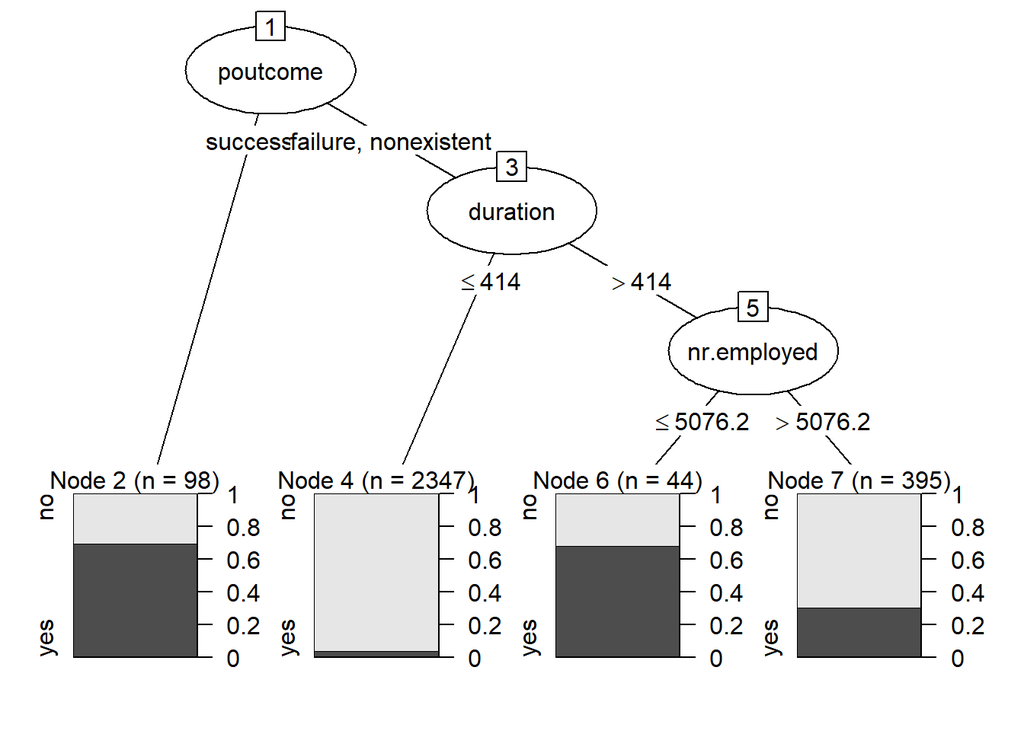

```r
# Plotting the non-complex tree with a CF value of 0.05

plot(decision_tree_model2)
```

```r
# Generating prediction for the new model with CF=0.05 for both the train and test set

model_2_train_predictions <- predict(decision_tree_model2,train_set)
model_2_test_predictions <- predict(decision_tree_model2,test_set)

# Creating confusion matrix for both the train and test set data for the new model

Confusion_Matrix_train_2 <- table(predicted = model_2_train_predictions,
                                  observed = train_set$y)
Confusion_Matrix_train_2
```

```
##          observed
## predicted   no  yes
##       no  2524  218
##       yes   44   98
```

```r
Confusion_Matrix_test_2 <- table(predicted = model_2_test_predictions,
                                  observed = test_set$y)
Confusion_Matrix_test_2
```

```
##          observed
## predicted   no  yes
##       no  1076   99
##       yes   24   36
```

```r
# Checking for accuracy of how the model performed on both the train and test datasets

mmetric(train_set$y, model_2_train_predictions, metric="ACC")
```

```
## [1] 90.9154
```

```r
mmetric(test_set$y, model_2_test_predictions, metric = "ACC")
```

```
## [1] 90.04049
```

# 4 Simple Naïve Bayes Model Training and Testing

```r
# Creating a simple Naive Bayes Model from the training set

naive_model1 <- naiveBayes(y ~ ., data = train_set)
naive_model1
```

```
##
## Naive Bayes Classifier for Discrete Predictors
##
## Call:
## naiveBayes.default(x = X, y = Y, laplace = laplace)
##
## A-priori probabilities:
## Y
##      no     yes
## 0.89043 0.10957
##
## Conditional probabilities:
##      age
## Y         [,1]      [,2]
##   no  39.84229  9.847911
##   yes 42.64557 13.676338
##
##      job
## Y          admin. blue-collar entrepreneur   housemaid  management     retired
##   no  0.230140187 0.227803738  0.040887850 0.027647975 0.084501558 0.035046729
##   yes 0.265822785 0.129746835  0.022151899 0.018987342 0.069620253 0.094936709
##      job
## Y     self-employed    services     student  technician  unemployed     unknown
##   no    0.039330218 0.095015576 0.017133956 0.166666667 0.024922118 0.010903427
##   yes   0.034810127 0.075949367 0.037974684 0.196202532 0.044303797 0.009493671
##
##      marital
## Y        divorced     married      single     unknown
##   no  0.109034268 0.615264798 0.272585670 0.003115265
##   yes 0.094936709 0.550632911 0.351265823 0.003164557
##
##      education
## Y       basic.4y   basic.6y   basic.9y high.school illiterate
##   no  0.10630841 0.05529595 0.15109034  0.22157321 0.00000000
##   yes 0.07911392 0.03797468 0.10759494  0.22784810 0.00000000
##      education
## Y     professional.course university.degree    unknown
##   no           0.12772586        0.30140187 0.03660436
##   yes          0.15822785        0.33544304 0.05379747
##
```

[output cut: 68 more lines]

```
##
##      cons.conf.idx
## Y          [,1]     [,2]
##   no  -40.54408 4.416817
##   yes -39.43766 5.868128
##
##      euribor3m
## Y         [,1]     [,2]
##   no  3.788662 1.645803
##   yes 2.171699 1.787961
##
##      nr.employed
## Y         [,1]     [,2]
##   no  5174.967 65.99472
##   yes 5094.490 90.89233
```

```r
summary(naive_model1)
```

```
##           Length Class  Mode
## apriori    2     table  numeric
## tables    20     -none- list
## levels     2     -none- character
## isnumeric 20     -none- logical
## call       4     -none- call
```

```r
# Generating prediction for the simple naive bayes model for both the train and test set

naive_model_1_train_predictions <- predict(naive_model1,train_set)
naive_model_1_test_predictions <- predict(naive_model1,test_set)

# Creating confusion matrix for both the train and test set data

Naive_Confusion_Matrix_train_1 <- table(predicted = naive_model_1_train_predictions,
                                  observed = train_set$y)
Naive_Confusion_Matrix_train_1
```

```
##          observed
## predicted   no  yes
##       no  2336  122
##       yes  232  194
```

```r
Naive_Confusion_Matrix_test_1 <- table(predicted = naive_model_1_test_predictions,
                                  observed = test_set$y)
Naive_Confusion_Matrix_test_1
```

```
##          observed
## predicted   no  yes
##       no  1003   60
##       yes   97   75
```

```r
# Checking for accuracy of how the model performed on both the train and test datasets

mmetric(train_set$y, naive_model_1_train_predictions, metric="ACC")
```

```
## [1] 87.72538
```

```r
mmetric(test_set$y, naive_model_1_test_predictions, metric = "ACC")
```

```
## [1] 87.28745
```

```r
# Using the C5imp() function to see the least important predictors from the previous decision tree model 1

C5imp(decision_tree_model1)
```

```
##                Overall
## poutcome        100.00
## duration         96.60
## nr.employed      96.46
## month            81.38
## job               6.76
## default           4.96
## day_of_week       3.40
## marital           2.25
## education         2.18
## age               1.35
## housing           0.55
## campaign          0.45
## euribor3m         0.42
## cons.conf.idx     0.21
## previous          0.17
## loan              0.00
## contact           0.00
## pdays             0.00
## emp.var.rate      0.00
## cons.price.idx    0.00
```

```r
# Creating a simple Naive Bayes Model from the training set without the predictor previous

naive_model2 <- naiveBayes(y ~ . - previous, data = train_set)
naive_model2
```

```
##
## Naive Bayes Classifier for Discrete Predictors
##
## Call:
## naiveBayes.default(x = X, y = Y, laplace = laplace)
##
## A-priori probabilities:
## Y
##      no     yes
## 0.89043 0.10957
##
## Conditional probabilities:
##      age
## Y         [,1]      [,2]
##   no  39.84229  9.847911
##   yes 42.64557 13.676338
##
##      job
## Y          admin. blue-collar entrepreneur   housemaid  management     retired
##   no  0.230140187 0.227803738  0.040887850 0.027647975 0.084501558 0.035046729
##   yes 0.265822785 0.129746835  0.022151899 0.018987342 0.069620253 0.094936709
##      job
## Y     self-employed    services     student  technician  unemployed     unknown
##   no    0.039330218 0.095015576 0.017133956 0.166666667 0.024922118 0.010903427
##   yes   0.034810127 0.075949367 0.037974684 0.196202532 0.044303797 0.009493671
##
##      marital
## Y        divorced     married      single     unknown
##   no  0.109034268 0.615264798 0.272585670 0.003115265
##   yes 0.094936709 0.550632911 0.351265823 0.003164557
##
##      education
## Y       basic.4y   basic.6y   basic.9y high.school illiterate
##   no  0.10630841 0.05529595 0.15109034  0.22157321 0.00000000
##   yes 0.07911392 0.03797468 0.10759494  0.22784810 0.00000000
##      education
## Y     professional.course university.degree    unknown
##   no           0.12772586        0.30140187 0.03660436
##   yes          0.15822785        0.33544304 0.05379747
##
```

[output cut: 63 more lines]

```
##
##      cons.conf.idx
## Y          [,1]     [,2]
##   no  -40.54408 4.416817
##   yes -39.43766 5.868128
##
##      euribor3m
## Y         [,1]     [,2]
##   no  3.788662 1.645803
##   yes 2.171699 1.787961
##
##      nr.employed
## Y         [,1]     [,2]
##   no  5174.967 65.99472
##   yes 5094.490 90.89233
```

```r
summary(naive_model2)
```

```
##           Length Class  Mode
## apriori    2     table  numeric
## tables    19     -none- list
## levels     2     -none- character
## isnumeric 19     -none- logical
## call       4     -none- call
```

```r
# Generating prediction for the new naive bayes model for both the train and test set

naive_model_2_train_predictions <- predict(naive_model2,train_set)
naive_model_2_test_predictions <- predict(naive_model2,test_set)

# Creating confusion matrix for both the train and test set data

Naive_Confusion_Matrix_train_2 <- table(predicted = naive_model_2_train_predictions,
                                  observed = train_set$y)
Naive_Confusion_Matrix_train_2
```

```
##          observed
## predicted   no  yes
##       no  2327  110
##       yes  241  206
```

```r
Naive_Confusion_Matrix_test_2 <- table(predicted = naive_model_2_test_predictions,
                                  observed = test_set$y)
Naive_Confusion_Matrix_test_2
```

```
##          observed
## predicted   no  yes
##       no  1002   54
##       yes   98   81
```

```r
# Checking for accuracy of how the model performed on both the train and test datasets

mmetric(train_set$y, naive_model_2_train_predictions, metric="ACC")
```

```
## [1] 87.8294
```

```r
mmetric(test_set$y, naive_model_2_test_predictions, metric = "ACC")
```

```
## [1] 87.69231
```

# 5 Create a Named Cross-validation Function – cv_function

The cv_function performs k-fold cross-validation on a dataset using a specified classification algorithm. It divides the data into training and testing sets for each fold, trains the model, and evaluates its performance using specified metrics. The results are aggregated to compute mean and standard deviation values, providing a concise summary of model performance across the folds.

```r
cv_function <- function(df, target, nFolds, seedVal, classification, metrics_list)
{
  set.seed(seedVal)
  folds = createFolds(df[,target],nFolds)

  cv_results <- lapply(folds, function(x)
  {
    train <- df[-x,-target]
    test  <- df[x,-target]

    train_target <- df[-x,target]
    test_target <- df[x,target]

    classification_model <- classification(train,train_target)

    pred<- predict(classification_model,test)

    return(mmetric(test_target,pred,c("ACC","PRECISION","TPR","F1")))

  })

  cv_results_m <- as.matrix(as.data.frame(cv_results))

  cv_mean<- as.matrix(rowMeans(cv_results_m))

  colnames(cv_mean) <- "Mean"

  cv_sd <- as.matrix(rowSds(cv_results_m))

  colnames(cv_sd) <- "Sd"

  cv_all <- cbind(cv_results_m, cv_mean, cv_sd)

  kable(cv_all,digits=2)
}
```

# 6 5-fold and 10-fold C5.0 and naive Bayes evaluation performance with cv_function

The code segment runs cross-validation (CV) evaluations for C5.0 and Naive Bayes classification models on a dataset. It first defines parameters for 5-fold and 10-fold CV, then utilizes the cv_function to evaluate model performance using accuracy, precision, true positive rate (TPR), and F1 score metrics. The process is repeated for both C5.0 and Naive Bayes models, providing insights into their performance across different folds.

```r
# Using the CV_Function to evaluate 5-fold and 10-fold C5.0 model evaluation performance.

# 5-fold, C5.0

df <- CD_balance
target <- 21
nFolds <- 5
seedVal <- 500
assign("classification", C5.0)
metrics_list <- c("ACC","PRECISION","TPR","F1")

cv_function(df, target, nFolds, seedVal, classification, metrics_list)
```

|  | Fold1 | Fold2 | Fold3 | Fold4 | Fold5 | Mean | Sd |
| --- | --- | --- | --- | --- | --- | --- | --- |
| ACC | 91.63 | 90.05 | 89.44 | 89.79 | 91.87 | 90.56 | 1.11 |
| PRECISION1 | 94.04 | 93.57 | 93.66 | 92.42 | 94.53 | 93.64 | 0.78 |
| PRECISION2 | 65.22 | 55.84 | 51.81 | 55.17 | 65.33 | 58.67 | 6.22 |
| TPR1 | 96.73 | 95.36 | 94.55 | 96.45 | 96.46 | 95.91 | 0.92 |
| TPR2 | 50.00 | 47.25 | 47.78 | 35.56 | 54.44 | 47.01 | 7.00 |
| F11 | 95.37 | 94.46 | 94.10 | 94.39 | 95.48 | 94.76 | 0.62 |
| F12 | 56.60 | 51.19 | 49.71 | 43.24 | 59.39 | 52.03 | 6.29 |

```r
# 10-fold, C5.0

df <- CD_balance
target <- 21
nFolds <- 10
seedVal <- 500
assign("classification", C5.0)
metrics_list <- c("ACC","PRECISION","TPR","F1")

cv_function(df, target, nFolds, seedVal, classification, metrics_list)
```

|  | Fold01 | Fold02 | Fold03 | Fold04 | Fold05 | Fold06 | Fold07 | Fold08 | Fold09 | Fold10 | Mean | Sd |
| --- | --- | --- | --- | --- | --- | --- | --- | --- | --- | --- | --- | --- |
| ACC | 90.78 | 90.29 | 88.81 | 89.56 | 91.02 | 90.05 | 92.48 | 91.75 | 89.83 | 92.46 | 90.70 | 1.23 |
| PRECISION1 | 94.10 | 93.83 | 92.55 | 93.55 | 94.12 | 94.54 | 94.21 | 93.70 | 92.88 | 94.67 | 93.81 | 0.68 |
| PRECISION2 | 58.97 | 56.41 | 48.57 | 52.50 | 60.53 | 54.35 | 71.88 | 67.74 | 55.88 | 69.44 | 59.63 | 7.74 |
| TPR1 | 95.64 | 95.37 | 95.08 | 94.82 | 95.91 | 94.28 | 97.55 | 97.28 | 95.91 | 96.99 | 95.88 | 1.09 |
| TPR2 | 51.11 | 48.89 | 37.78 | 46.67 | 51.11 | 55.56 | 51.11 | 46.67 | 41.30 | 55.56 | 48.57 | 5.71 |
| F11 | 94.86 | 94.59 | 93.80 | 94.18 | 95.01 | 94.41 | 95.85 | 95.45 | 94.37 | 95.82 | 94.83 | 0.70 |
| F12 | 54.76 | 52.38 | 42.50 | 49.41 | 55.42 | 54.95 | 59.74 | 55.26 | 47.50 | 61.73 | 53.37 | 5.70 |

```r
# Using the CV_Function to evaluate 5-fold and 10-fold naive Bayes model evaluation performance.

# 5-fold, naive Bayes

df <- CD_balance
target <- 21
nFolds <- 5
seedVal <- 500
assign("classification", naiveBayes)
metrics_list <- c("ACC","PRECISION","TPR","F1")

cv_function(df, target, nFolds, seedVal, classification, metrics_list)
```

|  | Fold1 | Fold2 | Fold3 | Fold4 | Fold5 | Mean | Sd |
| --- | --- | --- | --- | --- | --- | --- | --- |
| ACC | 86.53 | 87.50 | 84.83 | 87.85 | 88.35 | 87.01 | 1.39 |
| PRECISION1 | 93.57 | 95.13 | 95.38 | 95.41 | 95.18 | 94.93 | 0.77 |
| PRECISION2 | 40.37 | 45.24 | 38.56 | 46.03 | 47.46 | 43.53 | 3.85 |
| TPR1 | 91.14 | 90.59 | 87.19 | 90.72 | 91.55 | 90.24 | 1.74 |
| TPR2 | 48.89 | 62.64 | 65.56 | 64.44 | 62.22 | 60.75 | 6.77 |
| F11 | 92.34 | 92.80 | 91.10 | 93.01 | 93.33 | 92.52 | 0.87 |
| F12 | 44.22 | 52.53 | 48.56 | 53.70 | 53.85 | 50.57 | 4.15 |

```r
# 10-fold, naive Bayes

df <- CD_balance
target <- 21
nFolds <- 10
seedVal <- 500
assign("classification", naiveBayes)
metrics_list <- c("ACC","PRECISION","TPR","F1")

cv_function(df, target, nFolds, seedVal, classification, metrics_list)
```

|  | Fold01 | Fold02 | Fold03 | Fold04 | Fold05 | Fold06 | Fold07 | Fold08 | Fold09 | Fold10 | Mean | Sd |
| --- | --- | --- | --- | --- | --- | --- | --- | --- | --- | --- | --- | --- |
| ACC | 88.11 | 84.95 | 86.86 | 86.65 | 86.65 | 86.17 | 86.41 | 89.81 | 89.59 | 86.37 | 87.16 | 1.54 |
| PRECISION1 | 94.92 | 93.70 | 94.57 | 94.83 | 94.57 | 94.03 | 94.81 | 96.30 | 97.37 | 94.80 | 94.99 | 1.08 |
| PRECISION2 | 46.55 | 36.51 | 42.62 | 42.19 | 41.94 | 40.00 | 41.54 | 52.46 | 52.11 | 41.54 | 43.75 | 5.13 |
| TPR1 | 91.55 | 89.10 | 90.44 | 89.92 | 90.19 | 90.19 | 89.65 | 92.10 | 90.74 | 89.62 | 90.35 | 0.91 |
| TPR2 | 60.00 | 51.11 | 57.78 | 60.00 | 57.78 | 53.33 | 60.00 | 71.11 | 80.43 | 60.00 | 61.15 | 8.57 |
| F11 | 93.20 | 91.34 | 92.46 | 92.31 | 92.33 | 92.07 | 92.16 | 94.15 | 93.94 | 92.13 | 92.61 | 0.88 |
| F12 | 52.43 | 42.59 | 49.06 | 49.54 | 48.60 | 45.71 | 49.09 | 60.38 | 63.25 | 49.09 | 50.97 | 6.30 |

# 7 Reflections and Findings

The accuracy for the default decision tree model has a significant decrease from 93.34% to 90.60% suggesting that the model was probably a little overfitting on the train data set but not a lot.

For the 2nd decision tree model with a low CF value of 0.05, the Accuracy for both the train and testing data set is almost the same with only a decrease of 0.9% and the testing set accuracy is comparable with the default model as well with a value of 90.04%.

Moving on to the Naive Bayes models. For the first simple model the Testing and Training set predictions have almost the same accuracy with both having a difference of only about 0.5% with Training set having an accuracy of 87.73% and Testing set having an accuracy of 87.29% which is considerably low when compared to the test set accuracy of decision tree models having an accuracy of 90%.

This is due to the less complex nature of the naive bayes as it takes into account all the predictors rather than decision trees using C5.0 which has considers some predictors to be more important than others and looks for patterns and splits while naive bayes is mostly based on conditional probabilities of the predictors.

Upon doing cross validation for these models, the average accuracy remains same with 90% for decision tree models and around 87% for the naive bayes models suggesting that the model performance is stable and is not highly specific to the specific folds used in cross-validation. Hence, we can conclude that the models have generalized well to the data and there is very little over-fitting.